# R Tutorial at the WZB

Tasks for session 1 - Introduction

Markus Konrad

October 25, 2018

## Tasks

### 1. Install the package *MASS* (test on Windows)

Either use RStudio’s package manager (“Packages” tab in the lower left pane) or issue the following command on the console:

```r
install.packages('MASS')
```

### 2. Load the packages *MASS* and *tidyverse*

Let’s load the packages:

```r
library(MASS)
library(tidyverse)
```

**Loading these packages will produce some messages on the console. What do you think do they mean? (If you don’t know, just make a wild guess!)**

So if we would use the function `select()` now (you don’t need to know what it does for now), which one will be used – the one from *dplyr* or the one from *MASS*? This depends on the **order of package import**, i.e. the order of the above `library(...)` commands. The last imported package **always has precedence**, so in this case, `select()` from *dplyr* would be used. This process is called *masking*.

You can still access the masked function by using a **namespace prefix**. This means you prepend the package name and double colons to the function name like this: `MASS::select()` to specify which function from which package you want to use in case of a conflict.

### 3. Load the builtin dataset “cats” provided by the package MASS (Hint: Run `data(cats)` to load the data)

```r
data(cats)
```

### 4. Inform yourself about the data using R’s help system – What are the variables in the dataset?

```r
?cats
```

or:

```r
help(cats)
```

The variables in the dataset are:

- sex: Factor with levels “F” and “M”.
- Bwt: body weight in kg.
- Hwt: heart weight in g.

### 5. View the data using 4 different perspectives

**Issue simply the command `cats` at the console – What generally happens when you simply use an object’s name as command?**

```r
cats
```

```
##     Sex Bwt  Hwt
## 1     F 2.0  7.0
## 2     F 2.0  7.4
## 3     F 2.0  9.5
## 4     F 2.1  7.2
## 5     F 2.1  7.3
## 6     F 2.1  7.6
## 7     F 2.1  8.1
## 8     F 2.1  8.2
## 9     F 2.1  8.3
## 10    F 2.1  8.5
##  [ reached getOption("max.print") -- omitted 134 rows ]
```

**Using the functions `head` and `tail`. Inform yourself beforehand what these functions do (again, using the help system).**

`head(x, n)` and `tail(x, n)` return only the first or last `n` rows in a dataset `x`. Be default, `n` is 6.

```r
head(cats)
```

```
##   Sex Bwt Hwt
## 1   F 2.0 7.0
## 2   F 2.0 7.4
## 3   F 2.0 9.5
## 4   F 2.1 7.2
## 5   F 2.1 7.3
## 6   F 2.1 7.6
```

```r
tail(cats)
```

```
##     Sex Bwt  Hwt
## 139   M 3.6 15.0
## 140   M 3.7 11.0
## 141   M 3.8 14.8
## 142   M 3.8 16.8
## 143   M 3.9 14.4
## 144   M 3.9 20.5
```

**Using RStudios `View` function (use the function from the console and also check out the small table icon in the “Environment” tab in the top right pane)**

This will open a new tab in the main window pane with a data viewer.

```r
View(cats)
```

### 6. Construct a *scatter plot* of the data using `qplot` from the *ggplot2* package (incl. in *tidyverse*)

**Plot `Bwt` (body weight) on the x-axis and `Hwt` (heart weight) on the y-axis**

`qplot` is short for “quick plot”. The following specifies a scatter plot, where the first *parameter* is the variable on the x-axis, the second is the variable on the y-axis and the third parameter specifies the data to plot.

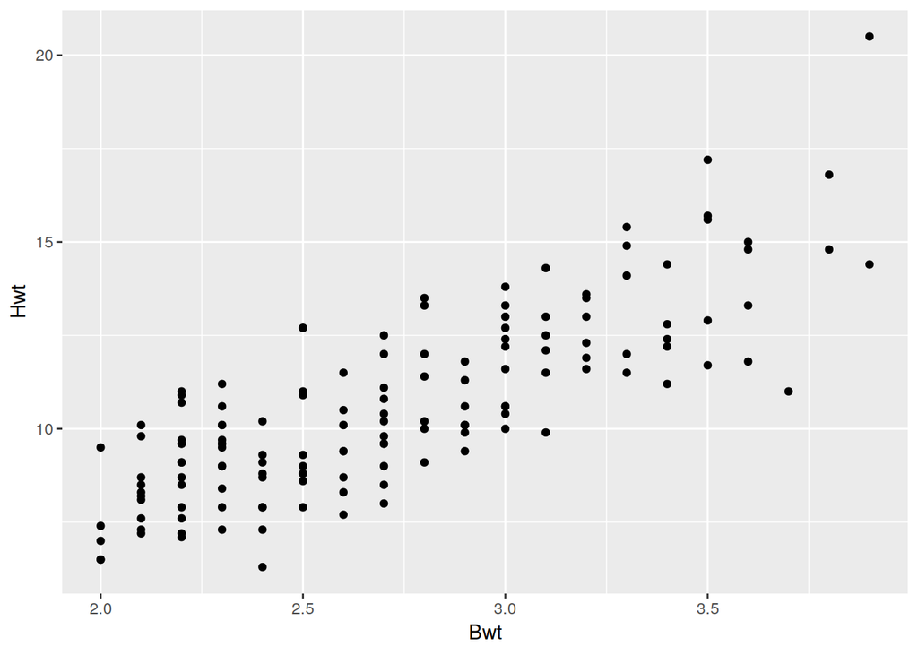

```r
qplot(Bwt, Hwt, data = cats)
```